# Self Sufficiency Final Report

Jacob Moore, Jaynae Wright, Mariama Mohamed Sani, Justice Demby

2025-05-01

```r
# Load libraries
library(tidyverse)
library(ggplot2)
library(scales)
library(ggforce)
library(kableExtra)
library(DT)
library(janitor)
library(ggalt)
```

### Data

```r
# Read data ----
cvl_person_5yr <- read_csv("../data/cvl_acspums_person_5year.csv") %>%
  # cleaning the names from the csv
  clean_names()
#2788 observations
```

```r
# loading in 5-year pums data for cville
cvl_house_5yr <- read_csv("../data/cvl_acspums_household_5year.csv") %>%
  # cleaning the names from the csv
  clean_names()

# removing vacant/institutional housing
cvl_house_5yr <- cvl_house_5yr %>%
  filter(typehugq == 1, is.na(vacs))

# generate variables for number of adults, number of children
# and reduce/combine to match famtype (in mit) or family (in epi)
cvl_house_5yr <- cvl_house_5yr %>%
  # number of people in household minus number of related children in household
  mutate(adults = np - nrc, # 1 to 7
         children = nrc, # 0 to 7
         # limit # adults to 2 (if > 2, treat as 2)
         adult_reduced = ifelse(adults > 2, 2, adults),
         # limit # children to 3 (to match famtype in mit)
         children_reduced3 = if_else(children > 3, 3, children),
         # limit # children to 4 (to match family in epi)
         children_reduced4 = if_else(children > 4, 4, children),
         famtype = paste0("a", adult_reduced, "c", children_reduced3),
         family = paste0(adult_reduced, "p", children_reduced4, "c"))
```

```r
# special thanks and credit to Professor Claibourn for providing us with code to join the self sufficiency data and PUMS data

# loading in mit living wage standards
# data currently has one observation for each family combination
mit <- read_csv("../data/cvlregion_mitlivingwagestandards.csv")

# altering the mit data so that family types only include number of adults and number of children
# essentially removing distinctions between how many adults in each household work
mit <- mit %>%
  mutate(famtype = str_remove(famtype, "w[0-9]"))

# reshaping the dataset to longer
mit <- mit %>%
  pivot_longer(-famtype, names_to = "county", values_to = "income") %>%
  # grouping by famtype
  group_by(famtype) %>%
  # aggregating data for different Charlottesville area counties
  summarize(income = (min(income) + max(income))/2) %>% # midpoint of range for each family type
  ungroup()
```

```r
# loading in economic policy institute data
epi <- read_csv("../data/cvlregion_epi_familybudget.csv")

# grouping by family type
epi <- epi %>%
  group_by(family) %>%
  # aggregating standards for the region as a whole
  summarize(budget = (min(total) + max(total))/2) %>% # midpoint of range for each family type
  ungroup()
```

# Introduction

This report seeks to investigate economic self sufficiency in the Greater Charlottesville region by leveraging **American Community Survey** data from the **US Census Bureau**. It employs two independently developed measures of economic self sufficiency, developed by the **Economic Policy Institute (EPI)** and the **Massachusetts Institute of Technology MIT)**, to uncover the interplay between race, gender, age, and educational attainment.

Overall, we seek to apply various measures of **economic self-sufficiency** with local data to explore how the region’s residents with diverse lived experiences have various degrees of fiscal agency.

**Use the tabs below to learn more about each measure of economic self sufficiency employed for this project.**

## MIT Living Wage Standard

The [MIT Living Wage Standard](https://livingwage.mit.edu/counties/51540) estimates the income required for working people to achieve a basic yet sufficient standard of living, considering family size (the number of adults and number of children) and regional cost variations. This metric serves as an economic security benchmark and a living wage indicator, offering a more precise alternative to the official poverty measure that has been criticized for being antiquated.

The standard is created based off of sufficient income needed to support a family depending on its composition. It takes into account costs such as food, child care, medical, housing, transportation, civic, internet and mobile, and “other.” It includes standards for households of one working adult, one working adult and one non-working adult, and two working adults. For each configuration of adults, there is a separate standard for zero, one, two, or three children.

**An initial glance at the count of households who are sufficient by the MIT self-sufficiency standards shows that 2,806 are sufficient and 2,020 are not.**

```r
## mit income ----
cvl_house_5yr <- cvl_house_5yr %>%
  left_join(mit, by = "famtype") %>%
  # using household income (hinc)
  mutate(mit_sufficient = if_else(hincp >= income, "Yes", "No"))
# "income" variable is for mit standards

cvl_house_5yr %>% count(mit_sufficient)
```

```
## # A tibble: 2 × 2
##   mit_sufficient     n
##   <chr>          <int>
## 1 No              2020
## 2 Yes             2806
```

## EPI Family Budget

Similar to the framework developed by MIT, the [EPI Family Budget](https://www.epi.org/resources/budget/) standards represent the household income needed for a family to live comfortably and with dignity. The standards rely, once again, on family composition, meaning the number of children and number of adults in a household. This measure likewise serves as a localized alternative to the standard poverty line employed by the government.

Unlike the MIT measure, the EPI Family Budget includes metro areas, not just localities. This allows for measurements based on groups of localities, like the Charlottesville region. EPI’s Charlottesville metro area includes the city of Charlottesville along with the counties of Albemarle, Nelson, Greene, and Fluvanna.

EPI’s measure likewise allows for family configurations of one or two adults with zero to four children. Notably, however, the metrics assume that both adults in two-adult households would be employed.

**For the EPI standards, 2,647 households are self-sufficient and 2,179 are not.**

```r
cvl_house_5yr <- cvl_house_5yr %>%
  left_join(epi, by = "family") %>%
  # using household income (hinc)
  mutate(epi_sufficient = if_else(hincp >= budget, "Yes", "No"))
# "budget" variable is for epi standards

cvl_house_5yr %>% count(epi_sufficient)
```

```
## # A tibble: 2 × 2
##   epi_sufficient     n
##   <chr>          <int>
## 1 No              2179
## 2 Yes             2647
```

# Salient Questions

Last year’s group chose to analyze economic self-sufficiency at the household level.

Below are areas for future analysis that we have from the work of last year’s group. *Click on any topic for more information.*

**Choosing a Unit of Analysis**

What were the trade-offs of this approach, and should we consider a different unit of analysis? Maybe person level?

**Thresholds for Individuals**

At personal levels, is the economic sufficiency threshold the same?  
How about individuals aged 18–24 working and living with their families?

**Household Structure**

Are nontraditional household structures (e.g., extended families, roommates) more economically resilient compared to single-parent households?

**Geographic Variations**

Could we explore cost-of-living differences within the region to see if self-sufficiency varies significantly across neighborhoods? Not sure if this is actually possible, but could be cool to explore.

**MIT Cost of Living**

While the MIT cost of living and other measures are based on cost of living for a given city, I am not sure that cost of living data exists that is this granular and yet, this would be awesome. Friends of mine certainly discuss neighborhoods in Charlottesville than are known to be more affordable. *Instead of just looking at income levels, we could analyze which industries and occupations are most associated with economic insecurity.

**Single-Parent Households**

Their project highlighted single-parent households as being disproportionately below the self-sufficiency threshold. Could we quantify how much of this disparity is driven by specific cost factors?

# A Launch Point

The [Orange Dot](https://communitypartnerships.virginia.edu/research/orange-dot-report-60-2024) project, developed by the [Center for Comminity Partnerships](https://communitypartnerships.virginia.edu) at the **University of Virginia**, shows the prevalence of families living below the economic sufficiency threshold in each locality. It likewise shows the share of families under the threshold by race and age.

Because Charlottesville is a “college town,” it may be interesting to further explore age trends in economic sufficiency.

# Age

[ALICE](https://www.unitedforalice.org), another economic sufficiency measure produced by United Way of New Jersey, shows some interesting, nearly quadratic trends in economic sufficiency with young and old people faring the worst while middle aged people tend to earn more sufficient wages. This motivates our investigation of economic self sufficiency by life stages.

## Defining Our Age Ranges

Age has been recoded into Life Stages as follows:

- **0–18**: “Adolescent”
- **19–24**: “Emerging Adulthood”
- **25–40**: “Early Adulthood”
- **41–64**: “Middle Adulthood”
- **65+**: “Late Adulthood”

## Who Lives in Charlottesville?

```r
# converting AGEP to a labeled factor
cvl_person_5yr <- cvl_person_5yr %>%
  mutate(life_stage = case_when(
    agep >= 0 & agep <= 18 ~ "Adolescent",
    agep >= 19 & agep <= 24 ~ "Emerging Adulthood",
    agep >= 25 & agep <= 40 ~ "Early Adulthood",
    agep >= 41 & agep <= 64 ~ "Middle Adulthood",
    agep >= 65 ~ "Late Adulthood"
  ))

cvl_person_5yr$life_stage <- factor(cvl_person_5yr$life_stage, levels = c("Adolescent", "Emerging Adulthood", "Early Adulthood", "Middle Adulthood", "Late Adulthood"))

# frequency table
age_table <- tabyl(cvl_person_5yr$life_stage) %>%
  adorn_pct_formatting(digits = 1)

age_table %>%
  kable("html",
        caption = "Percentage of Individuals by Life Stage",
        col.names = c("Life Stage", "n", "Percentage")) %>%
  kable_styling(
    full_width = FALSE,
    position = "center",
    font_size = 12,
    bootstrap_options = c("striped", "hover", "condensed")
  ) %>%
  column_spec(1, bold = TRUE) %>%
  column_spec(2, background = "darkorange")
```

Percentage of Individuals by Life Stage

| Life Stage | n | Percentage |
| --- | --- | --- |
| Adolescent | 2546 | 20.2% |
| Emerging Adulthood | 1525 | 12.1% |
| Early Adulthood | 2298 | 18.2% |
| Middle Adulthood | 3618 | 28.7% |
| Late Adulthood | 2622 | 20.8% |

# Income

## Two Measures of Income: `WAGP` vs `PINCP`

In the American Community Survey datasets, there are two measures of individual-level income that are importantly different in the types of income that they include. Careful comparison of the two is crucial for any analysis included in this project.

There is a notable visual difference between `WAGP` and `PINCP`. It is clear from the graph that, for many individuals in the dataset, the two measures of income are the same. Nevertheless, many individuals in the dataset have no income earned from wage labor but do receive income from other sources.

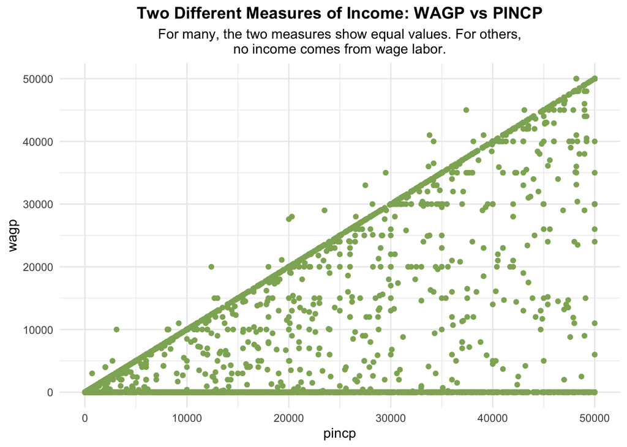

```r
# $50K or less
cvl_person_5yr %>%
  ggplot(aes(x = pincp, y = wagp)) +
  geom_point(color = "#8db064") +
  theme_minimal() +
  scale_y_continuous(limits = c(0, 50000)) +
  scale_x_continuous(limits = c(0, 50000)) +
  labs(title = "Two Different Measures of Income: WAGP vs PINCP",
       subtitle = "For many, the two measures show equal values. For others,\nno income comes from wage labor.") +
  theme(
    plot.title = element_text(hjust = 0.5, face = "bold"),
    plot.subtitle = element_text(hjust = 0.5)
  )
```

**Click on the tabs below to learn more about the two measures of income and see how the differ in mean and median values.**

### WAGP

`WAGP`, or a wages and salary income, measures only an individual’s earned income from labor. This means that it does not include transfer income from government programs, self-employment income, or any income from investments. `WAGP` is thus ideal for looking at poverty before social assistance or returns on assets have been factored in. Thsi means that on average `WAGP` will show lower values than `PINCP`.

```r
# mean and median for wagp
cvl_person_5yr %>%
  filter(agep >= 18) %>%
  summarize(
    mean_wage = mean(wagp),
    median_wage = median(wagp)
  ) %>%
  kable("html",
    digits = 2,
    col.names = c("Mean Wage", "Median Wage"),
    caption = "Summary of Wages (WAGP) for Individuals"
  ) %>%
  kable_styling(
    full_width = TRUE,
    position = "center",
    font_size = 12,
    bootstrap_options = c("striped", "hover", "condensed")
  ) %>%
  add_footnote(label = "Note: Includes all indivdiuals over the age of 18")
```

Summary of Wages (WAGP) for Individuals

| Mean Wage | Median Wage |
| --- | --- |
| 34735.97 | 8000 |

<sup>a</sup> Note: Includes all indivdiuals over the age of 18

### PINCP

`PINCP` by comparison includes all sources of income, meaning everything from wages to dividends to Social Security. This variable will be important in looking for ways that our existing welfare programs allow people to fall through the cracks while others float well above economic vulnerability. This would include people described as the “working poor.”

```r
cvl_person_5yr %>%
  filter(agep >= 18) %>%
  summarize(
    mean_wage = mean(pincp),
    median_wage = median(pincp)
  ) %>%
  kable("html",
    digits = 2,
    col.names = c("Mean Wage", "Median Wage"),
    caption = "Summary of Wages (PINCP) for Individuals"
  ) %>%
  kable_styling(
    full_width = TRUE,
    position = "center",
    font_size = 12,
    bootstrap_options = c("striped", "hover", "condensed")
  ) %>%
  add_footnote(label = "Note: Includes all indivdiuals over the age of 18")
```

Summary of Wages (PINCP) for Individuals

| Mean Wage | Median Wage |
| --- | --- |
| 51750.95 | 30000 |

<sup>a</sup> Note: Includes all indivdiuals over the age of 18

## Median Income Across the Life Course

Below we have a bar graph showing median personal income (PINCP) by age group. The first thing that stands out is the much smaller median income of those aged 18-24. The initial thought is that a great number of these individuals are full time students–whether in high school or in higher education–and thus are skewing the average.

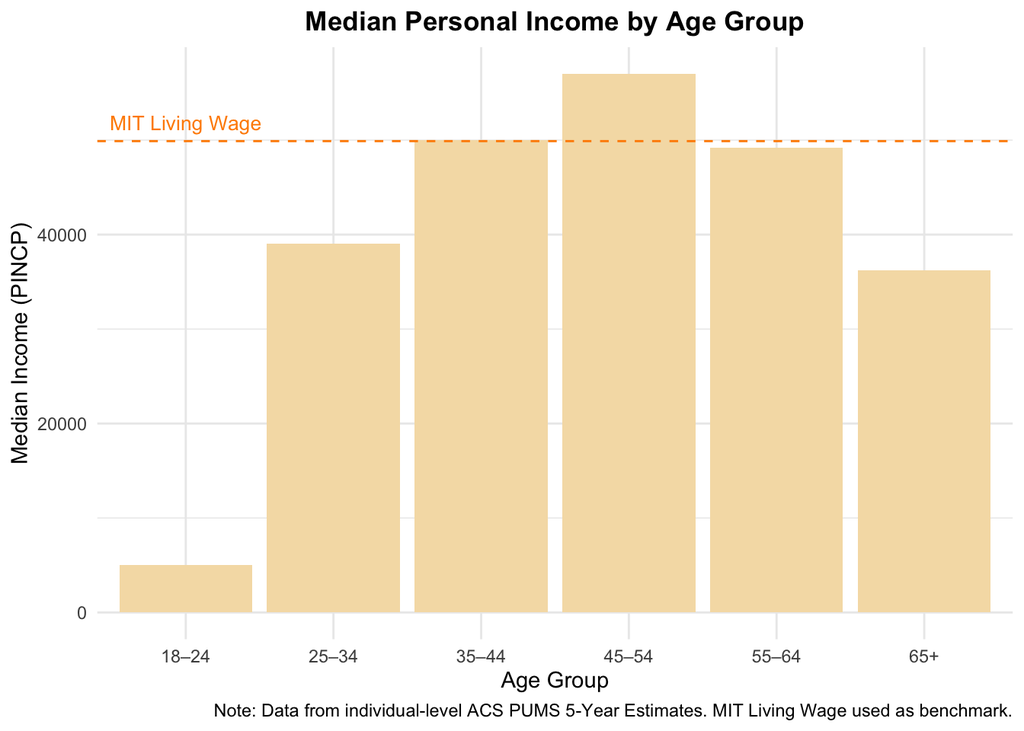

```r
# Create age groups and summarize median income
income_by_agegroup <- cvl_person_5yr %>%
  filter(pincp > 0, agep >= 18) %>%
  mutate(age_group = case_when(
    agep >= 18 & agep <= 24 ~ "18–24",
    agep >= 25 & agep <= 34 ~ "25–34",
    agep >= 35 & agep <= 44 ~ "35–44",
    agep >= 45 & agep <= 54 ~ "45–54",
    agep >= 55 & agep <= 64 ~ "55–64",
    agep >= 65 ~ "65+"
  )) %>%
  group_by(age_group) %>%
  summarize(median_income = median(pincp, na.rm = TRUE)) %>%
  arrange(age_group)

# Plot it
ggplot(income_by_agegroup, aes(x = age_group, y = median_income)) +
  geom_col(fill = "#f5deb3") +
  labs(title = "Median Personal Income by Age Group",
       x = "Age Group",
       y = "Median Income (PINCP)",
       caption = "Note: Data from individual-level ACS PUMS 5-Year Estimates. MIT Living Wage used as benchmark.") + geom_hline(yintercept = 49896, linetype = "dashed", color = "darkorange") +
  annotate("text",
           x = 1,
           y = 49896 + 2000,
           label = "MIT Living Wage",
           color = "darkorange",
           size = 3.5) +
  theme_minimal() +
  theme(
    plot.title = element_text(hjust = 0.5, face = "bold")
  )
```

## Income, Sex, & Age

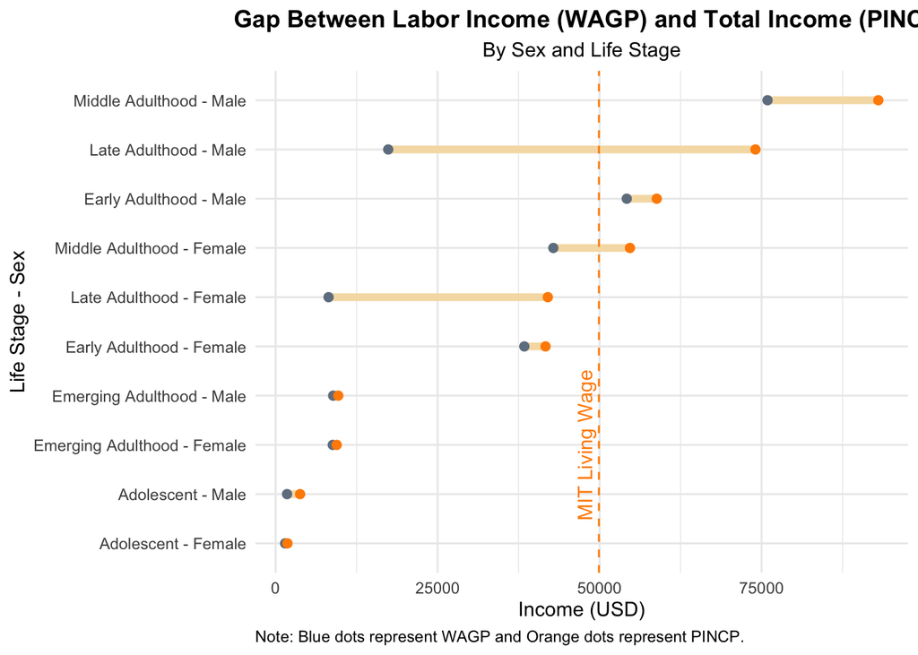

```r
average_wages <- cvl_person_5yr %>%
  group_by(sex, life_stage) %>%
  summarise(avg_pincp = mean(pincp, na.rm = TRUE),
            avg_wagp = mean(wagp, na.rm = TRUE)) %>%
  ungroup() %>%
  mutate(sex = factor(sex, levels = c(1, 2), labels = c("Male", "Female")),
         label = paste(life_stage, "-", sex))

ggplot(average_wages, aes(y = reorder(label, avg_pincp))) +
  # Create segments (lines between the two points)
  geom_segment(aes(x = avg_wagp, xend = avg_pincp, yend = label),
               color = "#f5deb3", size = 2) +  # Dumbbell line color
  # Add left points (WAGP)
  geom_point(aes(x = avg_wagp), color = "#708090", size = 2) +  # Left (WAGP) dots
  # Add right points (PINCP)
  geom_point(aes(x = avg_pincp), color = "#ff8c00", size = 2) +  # Right (PINCP) dots
  # Add title, subtitle, axes labels, and caption
  labs(
    title = "Gap Between Labor Income (WAGP) and Total Income (PINCP)",
    subtitle = "By Sex and Life Stage",
    x = "Income (USD)",
    y = "Life Stage - Sex",
    caption = "Note: Blue dots represent WAGP and Orange dots represent PINCP."
  ) +
  # Add a line for MIT Living Wage
  geom_vline(xintercept = 49896, linetype = "dashed", color = "darkorange") +
  # Annotate the line for MIT Living Wage
  annotate("text", y = 3, x = 50000, label = "MIT Living Wage", color = "darkorange", angle = 90, vjust = -0.5) +
  # Apply a minimal theme with custom text alignments
  theme_minimal() +
  theme(
    plot.title = element_text(face = "bold", hjust = 0.35),
    plot.subtitle = element_text(hjust = 0.5),
    plot.caption = element_text(hjust = 0)  # Align caption to the left
  )
```

# Educational Attainment

```r
# converting SCHL to a labeled factor
cvl_person_5yr <- cvl_person_5yr %>%
  mutate(educ = factor(schl,
                       levels = 1:24,
    labels = c(
      "No schooling completed",
      "Nursery school, preschool",
      "Kindergarten",
      "Grade 1",
      "Grade 2",
      "Grade 3",
      "Grade 4",
      "Grade 5",
      "Grade 6",
      "Grade 7",
      "Grade 8",
      "Grade 9",
      "Grade 10",
      "Grade 11",
      "12th grade - no diploma",
      "Regular high school diploma",
      "GED or alternative credential",
      "Some college, less than 1 year",
      "1+ years college, no degree",
      "Associate's degree",
      "Bachelor's degree",
      "Master's degree",
      "Professional degree",
      "Doctorate degree"
    )
  ))

# new data frame for only people no longer enrolled
# educational attainment table
educ_table <- cvl_person_5yr %>%
  filter(agep >= 18) %>%
  tabyl(educ) %>%
  adorn_pct_formatting(digits = 1)

educ_table %>%
  kable("html", caption = "Percentage of Individuals by Education Level 18+") %>%
  kable_styling(
    full_width = TRUE,
    position = "center",
    font_size = 12,
    bootstrap_options = c("striped", "hover", "condensed")
  ) %>%
  column_spec(1, bold = TRUE) %>%
  column_spec(3, background = "darkorange")
```

Percentage of Individuals by Education Level 18+

educ

n

percent

valid_percent

No schooling completed

0

0.0%

0.0%

Nursery school, preschool

0

0.0%

0.0%

Kindergarten

0

0.0%

0.0%

Grade 1

0

0.0%

0.0%

Grade 2

0

0.0%

0.0%

Grade 3

0

0.0%

0.0%

Grade 4

0

0.0%

0.0%

Grade 5

0

0.0%

0.0%

Grade 6

0

0.0%

0.0%

Grade 7

31

0.3%

0.3%

Grade 8

55

0.5%

0.5%

Grade 9

86

0.8%

0.8%

Grade 10

128

1.2%

1.2%

Grade 11

161

1.5%

1.6%

12th grade - no diploma

147

1.4%

1.4%

Regular high school diploma

1928

18.4%

18.7%

GED or alternative credential

320

3.1%

3.1%

Some college, less than 1 year

730

7.0%

7.1%

1+ years college, no degree

1583

15.1%

15.3%

Associate’s degree

569

5.4%

5.5%

Bachelor’s degree

2377

22.7%

23.0%

Master’s degree

1413

13.5%

13.7%

Professional degree

357

3.4%

3.5%

Doctorate degree

435

4.2%

4.2%

NA

156

1.5%

## Income, Educational Attainment, & Life Stage

Some interesting trends emerge if we look at Educational Attainment across Life Stages.

The table clearly shows that lower percentages of individuals in younger age cohorts have less than a high school degree. This makes sense considering we typically do not allow people to not finish K-12 nowadays.

Those in Emerging Adulthood (19-24) have a much higher percentage of individuals (more than 40 percent) with at least some college–a promising sign.

As for Bachelor’s degrees, we can see that with younger age cohorts, the percentage attaining increases: over 30 percent of those in Early Adulthood versus about 20 percent in Late Adulthood. Emerging Adulthood has the lowest percent, but this is most likely because it include people too young (19 to 21) to have yet completed a Bachelor’s degree.

Those with degrees higher than a Bachelor’s are comparable across Early, Middle, and Late Adulthood. The share of individuals in Emerging Adulthood with higher than a Bachelor’s degree is much lower, but this likely reflects the typical age at which a degree higher than a Bachelor’s is attained.

**Intersection of Age and Educational Attainment NOTE**

In the table below, keep in mind that excludes individuals who are below the age of 19; this is to ensure that individuals who have not completed high school are not included in the frequency table. (If these individuals were included, it would make it seem like approximately 20 percent of residents did not finish high school.)

```r
# restructuring the SCHL variable again into different categories
cvl_person_5yr <- cvl_person_5yr %>%
  mutate(highest_education = case_when(
    is.na(schl) ~ "Less than High School Degree",
    schl < 15 ~ "Less than High School Degree",
    schl == 16 | schl == 17 ~ "High School Degree",
    schl == 18 | schl == 19 ~ "Some College",
    schl == 20 ~ "Associate's Degree",
    schl == 21 ~ "Bachelor's Degree",
    schl >= 22 ~ "Above Bachelor's Degree"
  ))

cvl_person_5yr$highest_education <- factor(cvl_person_5yr$highest_education, levels = c("Less than High School Degree", "High School Degree", "Some College", "Associate's Degree", "Bachelor's Degree", "Above Bachelor's Degree"))

# filtered dataset
cvl_person_education <- cvl_person_5yr %>%
  filter(agep > 18)

# crosstabulation
educ_age_table <- cvl_person_education %>%
  tabyl(highest_education, life_stage) %>%
  adorn_percentages("col") %>%
  adorn_pct_formatting(digits = 1)

educ_age_table %>%
  kable("html", caption = "Percentage of Individuals by Education and Life Stage") %>%
  kable_styling(
    full_width = TRUE,
    position = "center",
    font_size = 12,
    bootstrap_options = c("striped", "hover", "condensed")
  ) %>%
  column_spec(1, bold = TRUE) %>%
  column_spec(2, background = "orange")
```

Percentage of Individuals by Education and Life Stage

highest_education

Adolescent

Emerging Adulthood

Early Adulthood

Middle Adulthood

Late Adulthood

Less than High School Degree

1.6%

4.3%

6.0%

9.2%

High School Degree

24.9%

16.4%

20.9%

21.1%

Some College

53.5%

13.6%

15.6%

16.7%

Associate’s Degree

3.4%

5.6%

6.8%

5.2%

Bachelor’s Degree

14.2%

29.9%

24.6%

22.3%

Above Bachelor’s Degree

1.4%

28.7%

24.5%

24.3%

NA

1.0%

1.6%

1.5%

1.1%

## Educational Attainment, Life Stage, & Economic Self Sufficiency

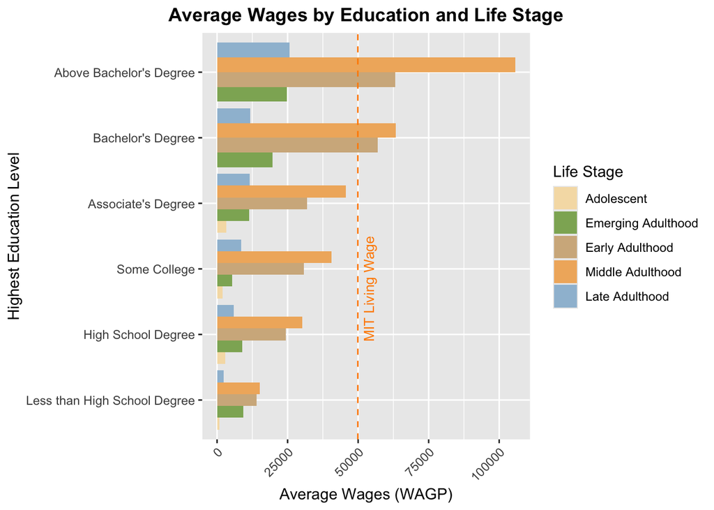

```r
# average income by educational attainment and age
summary_data <- cvl_person_5yr %>%
  filter(!is.na(highest_education), !is.na(agep), !is.na(wagp)) %>%
  group_by(highest_education, life_stage) %>%
  summarise(avg_wages = mean(wagp, na.rm = TRUE))

# graph of above
ggplot(summary_data, aes(x = highest_education, y = avg_wages, fill = life_stage)) +
  geom_bar(stat = "identity", position = "dodge") + geom_hline(yintercept = 49896, linetype = "dashed", color = "darkorange") +
  annotate("text", x = 2.7, y = 51896 + 2000, label = "MIT Living Wage", color = "darkorange", size = 3.5, angle = 90) +  scale_fill_manual(values = c(
    "Adolescent" = "#f5deb3",
    "Emerging Adulthood" = "#8db064",
    "Early Adulthood" = "#d2b48c",
    "Middle Adulthood" = "#f0b46c",
    "Late Adulthood" = "#9fbed6"
  )) +
  labs(
    title = "Average Wages by Education and Life Stage",
    x = "Highest Education Level",
    y = "Average Wages (WAGP)",
    fill = "Life Stage"
  ) +
  coord_flip() +
  theme(axis.text.x = element_text(angle = 45, hjust = 1),
        plot.title = element_text(hjust = 0.5, face = "bold")
  )
```

# Race

## Race & Income

The analysis of mean personal income by race reveals notable differences across racial groups.

**Click on the tabs below to explore mean income across races for both measures of income.**

### WAGP

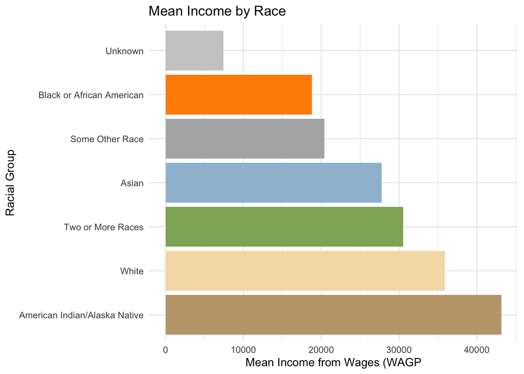

```r
# recoding RAC1P var
cvl_person_5yr <- cvl_person_5yr %>%
   mutate(race_group = case_when(
     rac1p == 1 ~ "White",
     rac1p == 2 ~ "Black or African American",
     rac1p == 3 ~ "American Indian/Alaska Native",
     rac1p == 6 ~ "Asian",
     rac1p == 8 ~ "Some Other Race",
     rac1p == 9 ~ "Two or More Races",
     TRUE ~ "Unknown"
   ))

# WAGP graph
cvl_person_5yr %>%
   group_by(race_group) %>%
   summarize(mean_income = mean(wagp, na.rm = TRUE)) %>%
   ggplot(aes(x = reorder(race_group, -mean_income), y = mean_income, fill = race_group)) +
   geom_col(show.legend = FALSE) +   scale_fill_manual(values = c(
    "White" = "#f5deb3",
    "Black or African American" = "darkorange",
    "Asian" = "#9fbed6",
    "American Indian/Alaska Native" = "#c1a57b",
    "Some Other Race" = "#b2b2b2",
    "Two or More Races" = "#8db064",
    "Unknown" = "#cccccc"
  )) +
   labs(title = "Mean Income by Race",
        x = "Racial Group",
        y = "Mean Income from Wages (WAGP") +
   theme_minimal() +
  coord_flip()
```

### PINCP

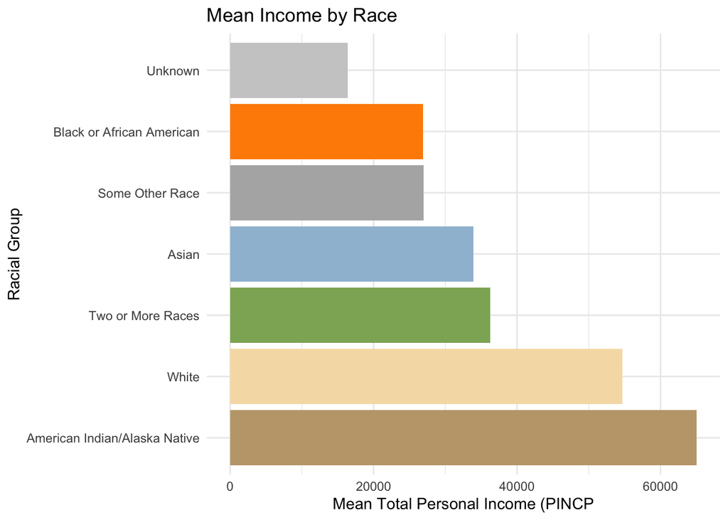

```r
# WAGP graph
cvl_person_5yr %>%
   group_by(race_group) %>%
   summarize(mean_income = mean(pincp, na.rm = TRUE)) %>%
   ggplot(aes(x = reorder(race_group, -mean_income), y = mean_income, fill = race_group)) +
   geom_col(show.legend = FALSE) +   scale_fill_manual(values = c(
    "White" = "#f5deb3",
    "Black or African American" = "darkorange",
    "Asian" = "#9fbed6",
    "American Indian/Alaska Native" = "#c1a57b",
    "Some Other Race" = "#b2b2b2",
    "Two or More Races" = "#8db064",
    "Unknown" = "#cccccc"
  )) +
   labs(title = "Mean Income by Race",
        x = "Racial Group",
        y = "Mean Total Personal Income (PINCP") +
   theme_minimal() +
  coord_flip()
```

## Race and Economic Self Sufficiency

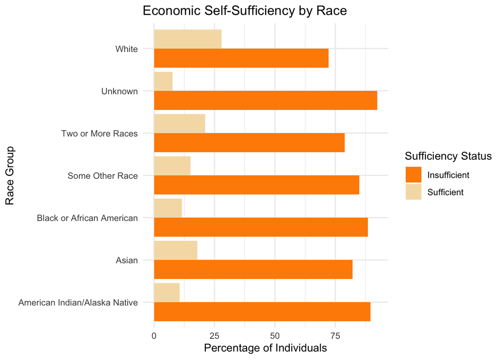

```r
#MIT sufficiency

# sufficiency cutoff
cvl_person_5yr <- cvl_person_5yr %>%
   mutate(
     sufficient_income = case_when(
       pernp >= 49896 ~ "Sufficient",
       pernp < 49896 ~ "Insufficient",
       TRUE ~ NA_character_
     ))

# graph
cvl_person_5yr %>%
   filter(!is.na(sufficient_income)) %>%  # REMOVE NA rows
  group_by(race_group, sufficient_income) %>%
  summarize(count = n()) %>%
  group_by(race_group) %>%
  mutate(percent = count / sum(count) * 100) %>%
  ggplot(aes(x = race_group, y = percent, fill = sufficient_income)) +
  geom_col(position = "dodge") + scale_fill_manual(values = c(
    "Sufficient" = "#f5deb3",  "Insufficient" = "darkorange")) +
  labs(
    title = "Economic Self-Sufficiency by Race",
    x = "Race Group",
    y = "Percentage of Individuals",
    fill = "Sufficiency Status"
  ) +
  theme_minimal() +
  coord_flip()
```

# Household Size

After weighing the data, it looks like about 29 percent of households have one member and about 37 percent have two members. About 14 percent of households have 3 members. This is a bit surprising considering that I would expect a good share of households to have children, which could belong to households with 2 or more individuals.

```r
# table for number of people per household
cvl_house_5yr %>%
  # group by household size
  group_by(`Size of Household` = np) %>%
  # getting the weighted number of households
  summarize(weighted_total = sum(wgtp, na.rm = TRUE)) %>%
  mutate(
    # weighted total divided by the sum of the weighted total times 100
    `Percent of Households` = weighted_total / sum(weighted_total) * 100,
    # rounding percent to 2 digits
    `Percent of Households` = round(`Percent of Households`, 2)
  ) %>%
  # selecting vars to put in table
  select(`Size of Household`, `Percent of Households`) %>%
  # formatting caption, middle alighing text
  kable(format = "markdown", caption = "Proportion of Households by Number of People (Weighted)", align = "c") %>%
  # making the table not take the full space in RMD
  kable_styling(full_width = FALSE)
```

Proportion of Households by Number of People (Weighted)

| Size of Household | Percent of Households |
| --- | --- |
| 1 | 29.30 |
| 2 | 37.30 |
| 3 | 13.92 |
| 4 | 11.76 |
| 5 | 4.93 |
| 6 | 1.74 |
| 7 | 0.73 |
| 8 | 0.24 |
| 9 | 0.04 |
| 11 | 0.02 |
| 13 | 0.01 |

## SNAP

Weighing the data likewise reveals that just over 6 percent of households in the Charlottesville region receive SNAP benefits.

```r
# proportion of households with SNAP recipients (fs)
cvl_house_5yr %>%
  # group by SNAP status
  group_by(fs) %>%
  # getting a weighted total based on SNAP status
  summarize(weighted_total = sum(wgtp, na.rm = TRUE)) %>%
  mutate(
    # dividing by the weighted sum of households, multiply by 100
    `Percent of Households` = weighted_total / sum(weighted_total) * 100,
    # rounding to 2 digits
    `Percent of Households` = round(`Percent of Households`, 2)
  ) %>%
  # selecting vars for table
  select(fs, `Percent of Households`) %>%
  # renaming fs for graph
  rename(`SNAP Status` = fs) %>%
  # naming values for SNAP status
  mutate(`SNAP Status` = case_when(
    `SNAP Status` == 1 ~ "Received SNAP",
    `SNAP Status` == 2 ~ "Did Not Receive SNAP",
    TRUE ~ "Unknown"
  )) %>%
  # captioning table, aligning text to center
  kable(format = "markdown", caption = "Proportion of SNAP Recipients (Weighted)", align = "c") %>%
  # making the table not take the full space in RMD
  kable_styling(full_width = FALSE)
```

Proportion of SNAP Recipients (Weighted)

| SNAP Status | Percent of Households |
| --- | --- |
| Received SNAP | 6.24 |
| Did Not Receive SNAP | 93.76 |

### SNAP & Household Size

**Click on the tabs below to see the results for each measure.**

#### Overall

When looking at SNAP receipt by household size, after weighing, households of nine people were most likely to have at least one SNAP recipient (100%), followed by households of eight (24.9%) and households of five (19.28%). Households with more than four people are much more likely to have at least one SNAP recipient (aside from households with 11 and 13 people).

```r
# SNAP receipt by number of people in household
cvl_house_5yr %>%
  # grouping by np and fs
  group_by(`Household Size` = np, `SNAP Status` = fs) %>%
  # getting the weighted number of households, dropping groups
  summarize(weighted_total = sum(wgtp, na.rm = TRUE), .groups = "drop") %>%
  # making fs a factor
  mutate(`SNAP Status` = case_when(
    `SNAP Status` == 1 ~ "Received SNAP",
    `SNAP Status` == 2 ~ "Did Not Receive SNAP",
    TRUE ~ "Unknown"
  )) %>%
  # selecting vars for table
  select(`Household Size`, `SNAP Status`, weighted_total) %>%
  # switching to wide, one column for each SNAP status
  pivot_wider(names_from = `SNAP Status`, values_from = weighted_total, values_fill = 0) %>%
  # order by household size
  arrange(`Household Size`) %>%
  mutate(
    # calculating percent receving SNAP
    `Percent Receiving SNAP` = (`Received SNAP` / (`Received SNAP` + `Did Not Receive SNAP`)) * 100,
    # rounding, 2 digits
    `Percent Receiving SNAP` = round(`Percent Receiving SNAP`, 2)
  ) %>%
  # captioning, center aligned text
  kable(format = "markdown", caption = "Weighted Number of SNAP Recipients by Household Size", align = "c") %>%
  # making the table not take the full space in RMD
  kable_styling(full_width = FALSE)
```

Weighted Number of SNAP Recipients by Household Size

| Household Size | Received SNAP | Did Not Receive SNAP | Percent Receiving SNAP |
| --- | --- | --- | --- |
| 1 | 1797 | 28145 | 6.00 |
| 2 | 1366 | 36754 | 3.58 |
| 3 | 930 | 13297 | 6.54 |
| 4 | 821 | 11202 | 6.83 |
| 5 | 972 | 4069 | 19.28 |
| 6 | 273 | 1507 | 15.34 |
| 7 | 115 | 626 | 15.52 |
| 8 | 62 | 187 | 24.90 |
| 9 | 44 | 0 | 100.00 |
| 11 | 0 | 20 | 0.00 |
| 13 | 0 | 15 | 0.00 |

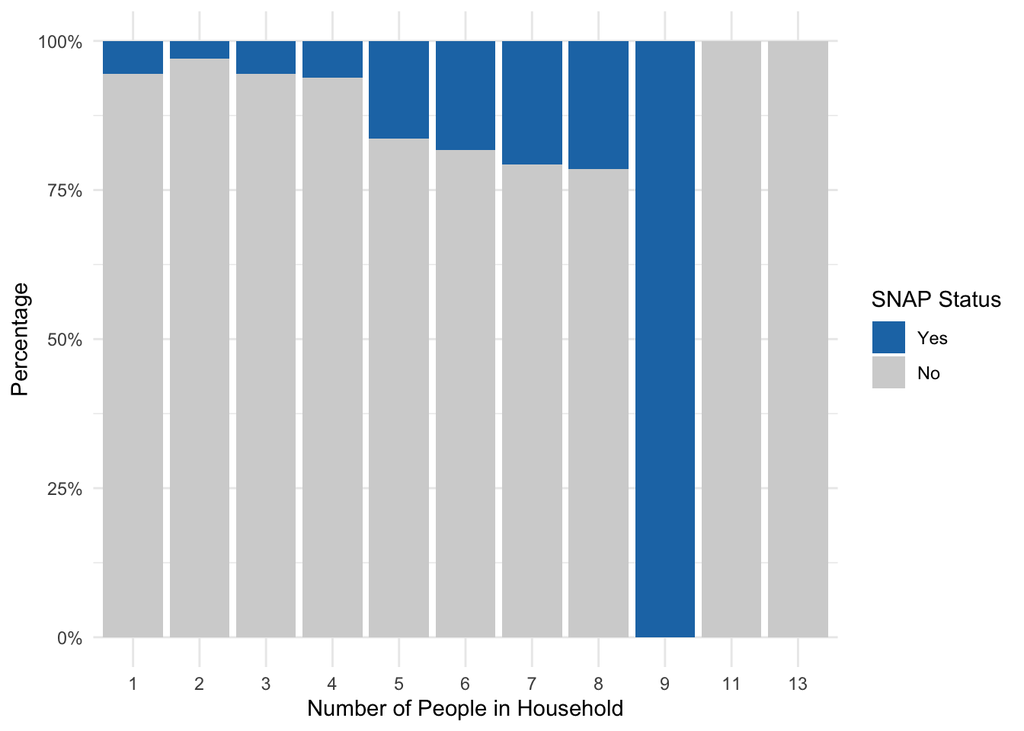

```r
# graph of above data
# shows percent of households that have a SNAP recipient by household size
cvl_house_5yr %>%
  # filtering to exclude cases where household size is 0 and SNAP status is NA
  filter(np != 0, !is.na(fs)) %>%
  # # people is on X axis, the bar fill is SNAP status
  ggplot(aes(x = factor(np), fill = factor(fs))) +
  # bar chart, filled
  geom_bar(position = "fill") +
  # formatting Y axis to be percents
  scale_y_continuous(labels = scales::percent_format()) +
  # manually picking colors for SNAP receipt and adding labels
  scale_fill_manual(
    values = c("1" = "#1f77b4", "2" = "#d3d3d3"),
    labels = c("1" = "Yes", "2" = "No")
  ) +
  # labels for X, Y, and legend
  labs(x = "Number of People in Household",
       y = "Percentage",
       fill = "SNAP Status") +
  theme_minimal()
```

#### Only Households with Related Children

After subsetting the data so that it only includes households with related children, the proportion of two-person households with a SNAP recipient jumps from less than 4 percent to more than 17 percent. Three- and four-person households, however, do not experience a similar jump. Like before, households with more than 5 members are much more likely to have at least one SNAP recipient compared to smaller household sizes (excluding households with 13 members).

```r
# by number of people in household, only households w/ related children
# SNAP receipt by number of people in household
cvl_house_5yr %>%
  # filtering to only households w/ related children
  filter(fparc %in% c(1, 2, 3)) %>%
  # grouping by np and fs
  group_by(`Household Size` = np, `SNAP Status` = fs) %>%
  # getting the weighted number of households, dropping groups
  summarize(weighted_total = sum(wgtp, na.rm = TRUE), .groups = "drop") %>%
  # making fs a factor
  mutate(`SNAP Status` = case_when(
    `SNAP Status` == 1 ~ "Received SNAP",
    `SNAP Status` == 2 ~ "Did Not Receive SNAP",
    TRUE ~ "Unknown"
  )) %>%
  # selecting vars for table
  select(`Household Size`, `SNAP Status`, weighted_total) %>%
  # switching to wide, one column for each SNAP status
  pivot_wider(names_from = `SNAP Status`, values_from = weighted_total, values_fill = 0) %>%
  # order by household size
  arrange(`Household Size`) %>%
  mutate(
    # calculating percent receving SNAP
    `Percent Receiving SNAP` = (`Received SNAP` / (`Received SNAP` + `Did Not Receive SNAP`)) * 100,
    # rounding, 2 digits
    `Percent Receiving SNAP` = round(`Percent Receiving SNAP`, 2)
  ) %>%
  # captioning, center aligned text
  kable(format = "markdown", caption = "Weighted Number of SNAP Recipients by Household Size", align = "c") %>%
  # making the table not take the full space in RMD
  kable_styling(full_width = FALSE)
```

Weighted Number of SNAP Recipients by Household Size

| Household Size | Received SNAP | Did Not Receive SNAP | Percent Receiving SNAP |
| --- | --- | --- | --- |
| 2 | 315 | 1483 | 17.52 |
| 3 | 579 | 6716 | 7.94 |
| 4 | 645 | 9222 | 6.54 |
| 5 | 966 | 3605 | 21.13 |
| 6 | 260 | 1476 | 14.98 |
| 7 | 115 | 479 | 19.36 |
| 8 | 62 | 173 | 26.38 |
| 9 | 44 | 0 | 100.00 |
| 13 | 0 | 15 | 0.00 |

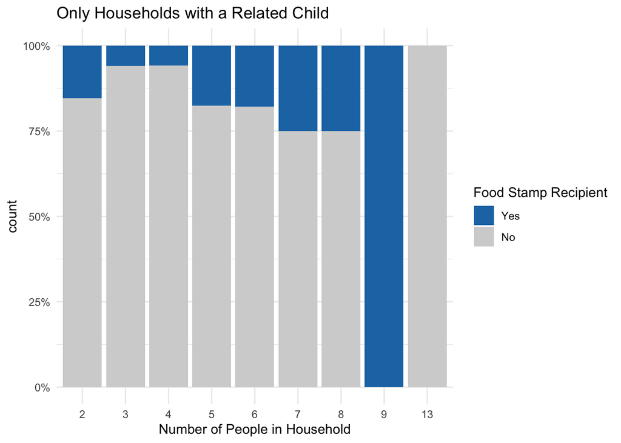

```r
# graph of above
cvl_house_5yr %>%
  filter(np != 0, !is.na(fs), fparc %in% c(1, 2, 3)) %>%
  ggplot(aes(x = factor(np), fill = factor(fs))) +
  geom_bar(position = "fill") +
  scale_y_continuous(labels = scales::percent_format()) +
  scale_fill_manual(
    values = c("1" = "#1f77b4", "2" = "#d3d3d3"),
    labels = c("1" = "Yes", "2" = "No")
  ) +
  theme_minimal() +
  labs(x = "Number of People in Household",
       fill = "Food Stamp Recipient",
       title = "Only Households with a Related Child")
```

## Household Size and Economic Self Sufficiency

With each of the household sizes below, the takeaways from each will vary in how revealing they are. For example, households with five or more members only make up 7.71 percent of the data set. What this means is that the findings about self-sufficiency for a household of, say, 13 people will not be too generalizable.

**Click on the tabs below to see the results for each measure.**

### MIT

According to MIT’s self-sufficiency standards, households with a size of one have the highest share of people below self-sufficiency (~62 percent) aside from households of 9 and 11. A higher share of 2 person households are insufficient (~35 percent) compared to households of 3 (~31 percent).

```r
# MIT sufficient receipt by number of people in household
cvl_house_5yr %>%
  # grouping by np and mit_sufficient
  group_by(`Household Size` = np, `Self-Sufficient` = mit_sufficient) %>%
  # getting the weighted number of households, dropping groups
  summarize(weighted_total = sum(wgtp, na.rm = TRUE), .groups = "drop") %>%
  # making sure mit_sufficient is labeled correctly
  mutate(`Self-Sufficient` = case_when(
    `Self-Sufficient` == "Yes" ~ "Self-Sufficient",
    `Self-Sufficient` == "No" ~ "Not Self-Sufficient",
    TRUE ~ "Unknown"
  )) %>%
  # selecting vars for table
  select(`Household Size`, `Self-Sufficient`, weighted_total) %>%
  # switching to wide format
  pivot_wider(names_from = `Self-Sufficient`, values_from = weighted_total, values_fill = 0) %>%
  # order by household size
  arrange(`Household Size`) %>%
  # calculate percent not self-sufficient
  mutate(
    `Percent Not Self-Sufficient` = (`Not Self-Sufficient` / (`Not Self-Sufficient` + `Self-Sufficient`)) * 100,
    `Percent Not Self-Sufficient` = round(`Percent Not Self-Sufficient`, 2)
  ) %>%
  # render table
  kable(format = "markdown", caption = "Weighted Number of Self-Sufficient Households by Household Size", align = "c") %>%
  kable_styling(full_width = FALSE)
```

Weighted Number of Self-Sufficient Households by Household Size

| Household Size | Not Self-Sufficient | Self-Sufficient | Percent Not Self-Sufficient |
| --- | --- | --- | --- |
| 1 | 18668 | 11274 | 62.35 |
| 2 | 13501 | 24619 | 35.42 |
| 3 | 4358 | 9869 | 30.63 |
| 4 | 5466 | 6557 | 45.46 |
| 5 | 2356 | 2685 | 46.74 |
| 6 | 689 | 1091 | 38.71 |
| 7 | 311 | 430 | 41.97 |
| 8 | 83 | 166 | 33.33 |
| 9 | 44 | 0 | 100.00 |
| 11 | 20 | 0 | 100.00 |
| 13 | 0 | 15 | 0.00 |

### EPI

Like with the MIT self-sufficiency standards, households with a size of one have the highest proportion of insufficiency, with about 67 percent of those households being insufficient (excluding households with a size of 9 or 11). More 2 person households are insufficient (~38 percent) than 3 person households (~33 percent).

```r
# EPI sufficient receipt by number of people in household
cvl_house_5yr %>%
  # grouping by np and mit_sufficient
  group_by(`Household Size` = np, `Self-Sufficient` = epi_sufficient) %>%
  # getting the weighted number of households, dropping groups
  summarize(weighted_total = sum(wgtp, na.rm = TRUE), .groups = "drop") %>%
  # making sure mit_sufficient is labeled correctly
  mutate(`Self-Sufficient` = case_when(
    `Self-Sufficient` == "Yes" ~ "Self-Sufficient",
    `Self-Sufficient` == "No" ~ "Not Self-Sufficient",
    TRUE ~ "Unknown"
  )) %>%
  # selecting vars for table
  select(`Household Size`, `Self-Sufficient`, weighted_total) %>%
  # switching to wide format
  pivot_wider(names_from = `Self-Sufficient`, values_from = weighted_total, values_fill = 0) %>%
  # order by household size
  arrange(`Household Size`) %>%
  # calculate percent not self-sufficient
  mutate(
    `Percent Not Self-Sufficient` = (`Not Self-Sufficient` / (`Not Self-Sufficient` + `Self-Sufficient`)) * 100,
    `Percent Not Self-Sufficient` = round(`Percent Not Self-Sufficient`, 2)
  ) %>%
  # render table
  kable(format = "markdown", caption = "Weighted Number of Self-Sufficient Households by Household Size", align = "c") %>%
  kable_styling(full_width = FALSE)
```

Weighted Number of Self-Sufficient Households by Household Size

| Household Size | Not Self-Sufficient | Self-Sufficient | Percent Not Self-Sufficient |
| --- | --- | --- | --- |
| 1 | 20154 | 9788 | 67.31 |
| 2 | 14390 | 23730 | 37.75 |
| 3 | 4744 | 9483 | 33.35 |
| 4 | 5988 | 6035 | 49.80 |
| 5 | 2672 | 2369 | 53.01 |
| 6 | 1023 | 757 | 57.47 |
| 7 | 337 | 404 | 45.48 |
| 8 | 101 | 148 | 40.56 |
| 9 | 44 | 0 | 100.00 |
| 11 | 20 | 0 | 100.00 |
| 13 | 0 | 15 | 0.00 |

# Family Presence and Related Children

We’ll now turn to exploring the datasets based on the variable `fparc`, which provides information about two things:

1. whether a household is a family
2. whether the household has any related children.

The overwhelming number of households in the Charlottesville region either are not families (38.3 percent) or contain no related children (36 percent). Nearly 17 percent of households contain related children that are between 5 and 17 years old. This is the largest category that contains related children.

```r
# variable showing family presence and age of related children
cvl_house_5yr %>%
  # weighted count using wgtp and name the count column
  count(fparc, wt = wgtp, name = "Weighted Count") %>%
  # calculate weighted percentages
  mutate(Percentage = `Weighted Count` / sum(`Weighted Count`) * 100) %>%
  # recode fparc for readability
  mutate(fparc = case_when(
    fparc == 1 ~ "Related Children, under 5",
    fparc == 2 ~ "Related Children, 5-17",
    fparc == 3 ~ "Related Children, under 5 and 5-17",
    fparc == 4 ~ "No Related Children",
    TRUE ~ "GQ/vacant/not a family"
  )) %>%
  # create formatted table
  kable(format = "markdown", caption = "Family Presence and Age of Related Children (Weighted)", align = "lcc") %>%
  kable_styling(full_width = FALSE)
```

Family Presence and Age of Related Children (Weighted)

| fparc | Weighted Count | Percentage |
| --- | --- | --- |
| Related Children, under 5 | 4608 | 4.508718 |
| Related Children, 5-17 | 17328 | 16.954658 |
| Related Children, under 5 and 5-17 | 4219 | 4.128099 |
| No Related Children | 36906 | 36.110839 |
| GQ/vacant/not a family | 39141 | 38.297685 |

## Household Size & Family Presence and Related Children

Looking at family presence and related children by the number of people in the household, the most popular combinations are a household size of 2 with no related children (1,524 households) and households with one member that is not a family (1,381 households). Curiously, for households of 3 people, the biggest portion of them contain no related children (261 households).

```r
#by number of people in household
cvl_house_5yr %>%
  # labels for values of fparc
  mutate(fparc = case_when(
    fparc == 1 ~ "Related Children, under 5",
    fparc == 2 ~ "Related Children, 5-17",
    fparc == 3 ~ "Related Children, under 5 and 5-17",
    fparc == 4 ~ "No Related Children",
    TRUE ~ "GQ/vacant/not a family"
  )) %>%
  # counting cases in np and fparc
  count(`Household Size` = np, `Family Presence and Related Children` = fparc) %>%
  # restructuring to wide
  pivot_wider(names_from = `Family Presence and Related Children`,
              values_from = n, values_fill = 0) %>%
  # arranging by values of np
  arrange(`Household Size`) %>%
  # kable formatting, caption and center alignment
  kable(format = "markdown", caption = "Household Size by Family Presence and Related Children", align = "c") %>%
  kable_styling(full_width = FALSE)
```

Household Size by Family Presence and Related Children

| Household Size | GQ/vacant/not a family | No Related Children | Related Children, 5-17 | Related Children, under 5 | Related Children, under 5 and 5-17 |
| --- | --- | --- | --- | --- | --- |
| 1 | 1381 | 0 | 0 | 0 | 0 |
| 2 | 328 | 1524 | 70 | 8 | 0 |
| 3 | 61 | 261 | 230 | 120 | 4 |
| 4 | 37 | 69 | 287 | 55 | 67 |
| 5 | 3 | 17 | 125 | 14 | 48 |
| 6 | 1 | 3 | 42 | 3 | 22 |
| 7 | 3 | 2 | 10 | 0 | 14 |
| 8 | 2 | 0 | 4 | 1 | 7 |
| 9 | 0 | 0 | 0 | 0 | 1 |
| 11 | 1 | 0 | 0 | 0 | 0 |
| 13 | 0 | 0 | 0 | 0 | 1 |

## SNAP & Family Presence and Related Children

Out of all categories for fparc, the largest portion of households with at least one SNAP recipient are not a family (95 households). By comparison, the largest portion of non-SNAP households are households with no related children (1,823 households).

```r
# by SNAP recipient status
cvl_house_5yr %>%
  # labels for values of fs
  mutate(
    `SNAP Recipient` = case_when(
      fs == 1 ~ "Yes",
      fs == 2 ~ "No",
      TRUE ~ "Missing"
    ),
    # labels for fparc
    `Child Status` = case_when(
      fparc == 1 ~ "Related Children, under 5",
      fparc == 2 ~ "Related Children, 5-17",
      fparc == 3 ~ "Related Children, under 5 and 5-17",
      fparc == 4 ~ "No Related Children",
      TRUE ~ "GQ/vacant/not a family"
    )
  ) %>%
  # counting cases in fs and fparc
  count(`SNAP Recipient`, `Child Status`) %>%
  # restructing to wide
  pivot_wider(names_from = `Child Status`, values_from = n, values_fill = 0) %>%
  # kable formatting, caption and center alignment
  kable(format = "markdown", caption = "SNAP Receipt by Household Child Composition", align = "c") %>%
  kable_styling(full_width = FALSE)
```

SNAP Receipt by Household Child Composition

| SNAP Recipient | GQ/vacant/not a family | No Related Children | Related Children, 5-17 | Related Children, under 5 | Related Children, under 5 and 5-17 |
| --- | --- | --- | --- | --- | --- |
| No | 1722 | 1823 | 700 | 189 | 132 |
| Yes | 95 | 53 | 68 | 12 | 32 |

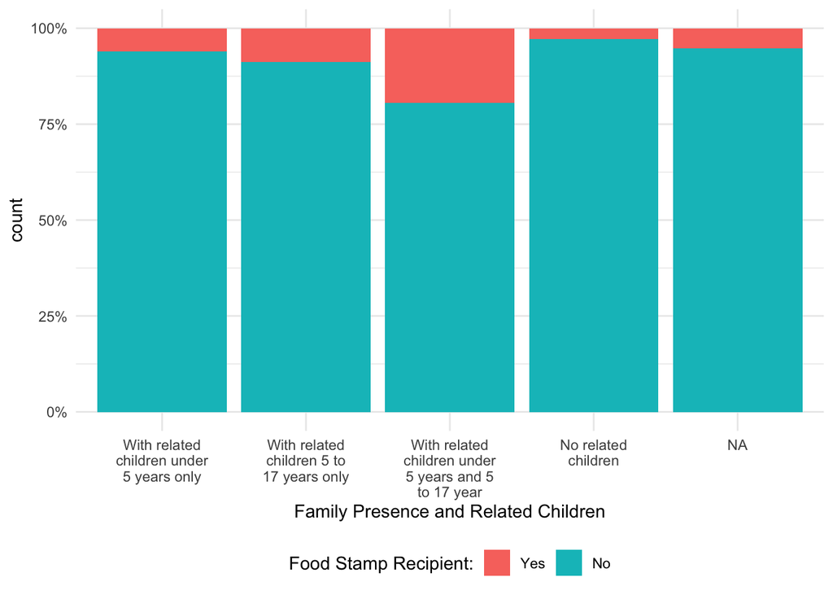

```r
# graph of the above
cvl_house_5yr %>%
  # filtering out NAs for SNAP status
  filter(!is.na(fs)) %>%
  # x values come from fparc, fs is fill of bars
  ggplot(aes(x = factor(fparc), fill = factor(fs))) +
  # filled bar chart
  geom_bar(position = "fill") +
  # formatting labels as percentaes
  scale_y_continuous(labels = scales::percent_format()) +
  # labeling the fill. categories
  scale_fill_discrete(labels = c("2" = "No", "1" = "Yes")) +
  # labeling values on X axis
  scale_x_discrete(labels = str_wrap(c(
    "1" = "With related children under 5 years only",
    "2" = "With related children 5 to 17 years only",
    "3" = "With related children under 5 years and 5 to 17 year",
    "4" = "No related children"
  ), 15)) +
  theme_minimal() +
  # labeling axes
  labs(x = "Family Presence and Related Children",
       fill = "Food Stamp Recipient:") +
  # legend at bottom, centered
  theme(
    legend.position = "bottom",
    legend.justification = "center",
    axis.title.y = element_text(hjust = 0.5)
  )
```